# act_report

## Report: act_report

- Create a **250-word-minimum written report** called "act_report.pdf" or "act_report.html" that communicates the insights and displays the visualization(s) produced from your wrangled data. This is to be framed as an external document, like a blog post or magazine article, for example.

### Insights and visualizations

Insights and visualizations were generated from the final master dataframe: twitter_archive_master from the wrangling process.

The twitter_archive_master contains the tweet ids, timestamps, texts displayed on the tweet, rtaings, dog breeds predictions and the amounts of likes and retweets. These columns are sufficient for us to communicate our final data without being superfluous.

All tweets used in this study was collected from 2015-11-15 to 2017-08-01 and a total of 1951 user tweets with adequate information was selected for inisghts and visualization. This is a long way from the 5000+ tweets at the very beginning of this project. This shows how redundant, dirty and messy data can be a large chunk of unreportable data.

The neural network was able to give 3 possible guesses to the dog breed in the image included in a particular tweet. From these guesses, we are able to check for the most occuring dog breed in our data, with golden retriever and Labrador retriever at the peak with an occurrence of 258.

[figure not shown]

Tweets are usually rated by the number of likes and retweets. In this data, user 744234799360020481, has the highest likes and retweets of 144410 and 70431 respectively.

Taking a look at the ratings, which is the main reason these dogs are being posted. We have a view of the range of ratings for the dogs and these ratings are on a scale of 10, but can be exceeded. Here, we see that most tweets rated dogs as 12/10, then between the range of 10 and 13. There are also some exaggerated ratings beyound the normal distribution of ratings.

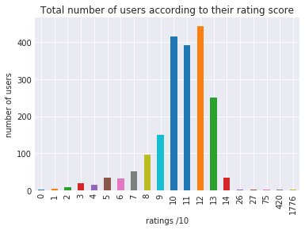